# Assignment 1- R Commands Exposure

Sam Eckhardt and Granger Moch

```r
suppressPackageStartupMessages(library(dplyr))
suppressPackageStartupMessages(library(ggplot2))
suppressPackageStartupMessages(library(gridExtra))
suppressPackageStartupMessages(library(scales))
suppressPackageStartupMessages(library(rCharts))
suppressPackageStartupMessages(library(car))
suppressPackageStartupMessages(library(Rcmdr))
```

```r
local({r <- getOption("repos");
       r["CRAN"] <- "http://cran.r-project.org"; options(repos=r)})

install.packages("nutshell")
data(births2006.smpl, package="nutshell")

??births2006.smpl
```

# 1 -

How many variables and how many observations are there?

```r
summary(births2006.smpl)
```

```
##      DOB_MM           DOB_WK          MAGER          TBO_REC
##  Min.   : 1.000   Min.   :1.000   Min.   :12.00   Min.   :1.000
##  1st Qu.: 4.000   1st Qu.:3.000   1st Qu.:23.00   1st Qu.:1.000
##  Median : 7.000   Median :4.000   Median :27.00   Median :2.000
##  Mean   : 6.601   Mean   :4.065   Mean   :27.37   Mean   :2.415
##  3rd Qu.:10.000   3rd Qu.:6.000   3rd Qu.:32.00   3rd Qu.:3.000
##  Max.   :12.000   Max.   :7.000   Max.   :50.00   Max.   :8.000
##                                                   NA's   :3134
##      WTGAIN      SEX            APGAR5
##  Min.   : 0.00   F:208653   Min.   : 0.00
##  1st Qu.:21.00   M:218670   1st Qu.: 9.00
##  Median :30.00              Median : 9.00
##  Mean   :30.83              Mean   : 8.86
##  3rd Qu.:40.00              3rd Qu.: 9.00
##  Max.   :98.00              Max.   :10.00
##  NA's   :75856              NA's   :58231
##                     DMEDUC          UPREVIS         ESTGEST
##  NULL                  :211059   Min.   : 0.00   Min.   :12.0
##  2 years of high school: 65462   1st Qu.: 9.00   1st Qu.:38.0
##  2 years of college    : 36713   Median :12.00   Median :39.0
##  3 years of college    : 24600   Mean   :13.96   Mean   :46.6
##  4 years of high school: 23863   3rd Qu.:14.00   3rd Qu.:40.0
##  3 years of high school: 15942   Max.   :99.00   Max.   :99.0
##  (Other)               : 49684
##      DMETH_REC                        DPLURAL            DBWT
##  C-section:132068   1 Single              :412979   Min.   : 227
##  Unknown  :  1517   2 Twin                : 13658   1st Qu.:2972
##  Vaginal  :293738   3 Triplet             :   642   Median :3310
##                     4 Quadruplet          :    39   Mean   :3265
##                     5 Quintuplet or higher:     5   3rd Qu.:3629
##                                                     Max.   :8165
##                                                     NA's   :434
```

```r
numOp=count(births2006.smpl)
numOp
```

```
## Source: local data frame [1 x 1]
##
##        n
## 1 427323
```

# 2 -

Which variables are numeric and which variables are factor?

```r
str(births2006.smpl)
```

```
## 'data.frame':    427323 obs. of  13 variables:
##  $ DOB_MM   : int  9 2 2 10 7 3 5 4 10 4 ...
##  $ DOB_WK   : int  1 6 2 5 7 3 2 7 3 4 ...
##  $ MAGER    : int  25 28 18 21 25 28 33 31 18 24 ...
##  $ TBO_REC  : int  2 2 2 2 1 3 2 3 1 2 ...
##  $ WTGAIN   : int  NA 26 25 6 36 35 26 25 46 43 ...
##  $ SEX      : Factor w/ 2 levels "F","M": 1 2 1 2 2 2 2 1 1 2 ...
##  $ APGAR5   : int  NA 9 9 9 10 8 9 9 9 9 ...
##  $ DMEDUC   : Factor w/ 18 levels "1 year of college",..: 18 4 18 18 6 18 18 4 18 6 ...
##  $ UPREVIS  : int  10 10 14 22 15 18 10 19 15 13 ...
##  $ ESTGEST  : int  99 37 38 38 40 39 38 38 40 40 ...
##  $ DMETH_REC: Factor w/ 3 levels "C-section","Unknown",..: 3 3 3 3 3 3 1 1 1 3 ...
##  $ DPLURAL  : Factor w/ 5 levels "1 Single","2 Twin",..: 1 1 1 1 1 1 1 1 1 1 ...
##  $ DBWT     : int  3800 3625 3650 3045 3827 3090 3430 3204 3227 3459 ...
```

# 3 -

Please re-label different months from numbers to name of months (1: January)

```r
births2006.smpl$DOB_MM= factor(births2006.smpl$DOB_MM,
labels= c('January', 'February','March','April','May', 'June', 'July', 'August', 'September', 'October', 'November', 'December'))
```

# 4 -

Plot a bar graph of number of deliveries by month.

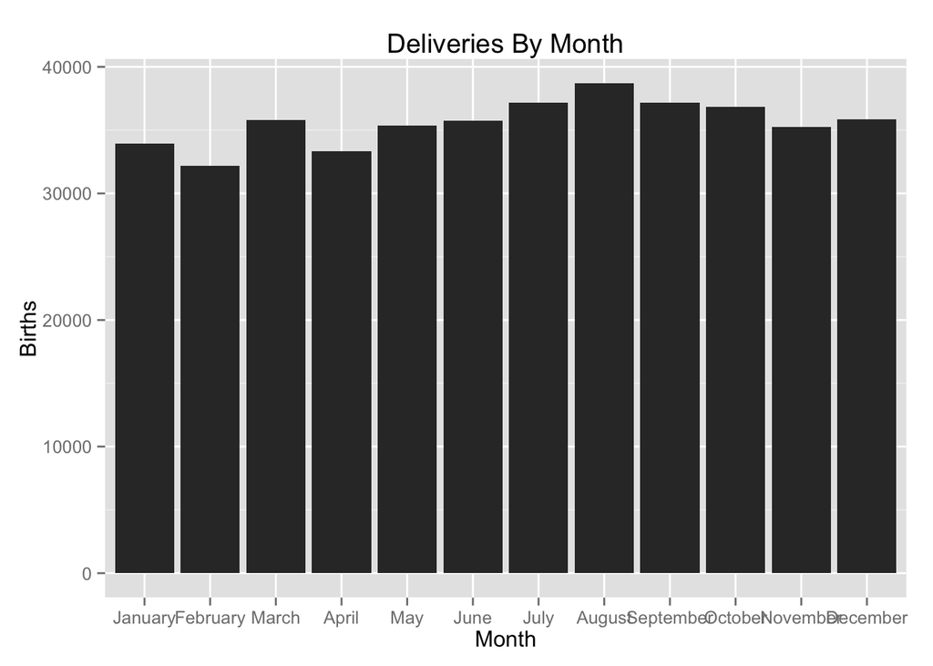

```r
deliveries_plot_month= ggplot(births2006.smpl, aes(x=DOB_MM)) + geom_bar() +xlab("Month") + ggtitle("Deliveries By Month") + ylab("Births")
deliveries_plot_month
```

# 5 -

Please re-label different days of week (1: Sunday)

```r
births2006.smpl$DOB_WK= factor(births2006.smpl$DOB_WK,
levels=c('1','2','3','4','5','6','7'),
labels=c('Sunday','Monday', 'Tuesday', 'Wednesday', 'Thursday', 'Friday', 'Saturday'))
```

# 6 -

Plot a bar graph of number of deliveries by day of week.

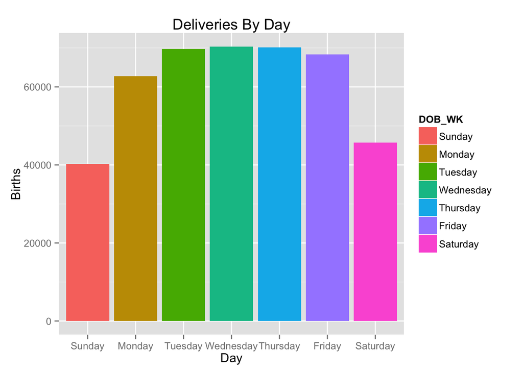

```r
deliveries_plot_day= ggplot(births2006.smpl, aes(x=DOB_WK, fill=DOB_WK, label=DOB_WK)) + geom_bar() +xlab("Day") + ggtitle("Deliveries By Day") + ylab("Births")
deliveries_plot_day
```

# 7 -

Plot histograms of Weight gains of mother and Birth weight of baby.

```
## stat_bin: binwidth defaulted to range/30. Use 'binwidth = x' to adjust this.
```

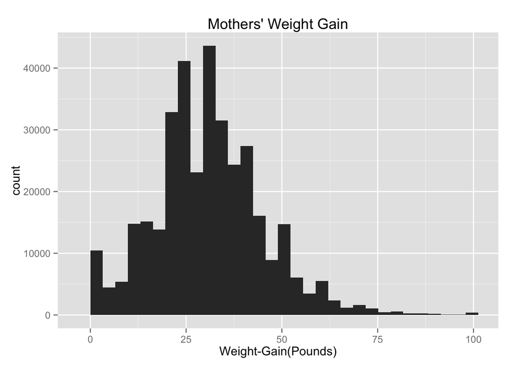

```r
wgainHisto= ggplot(births2006.smpl, aes(x=WTGAIN)) +geom_histogram() +xlab("Weight-Gain(Pounds)") +ggtitle("Mothers' Weight Gain")
wgainHisto
```

```
## stat_bin: binwidth defaulted to range/30. Use 'binwidth = x' to adjust this.
```

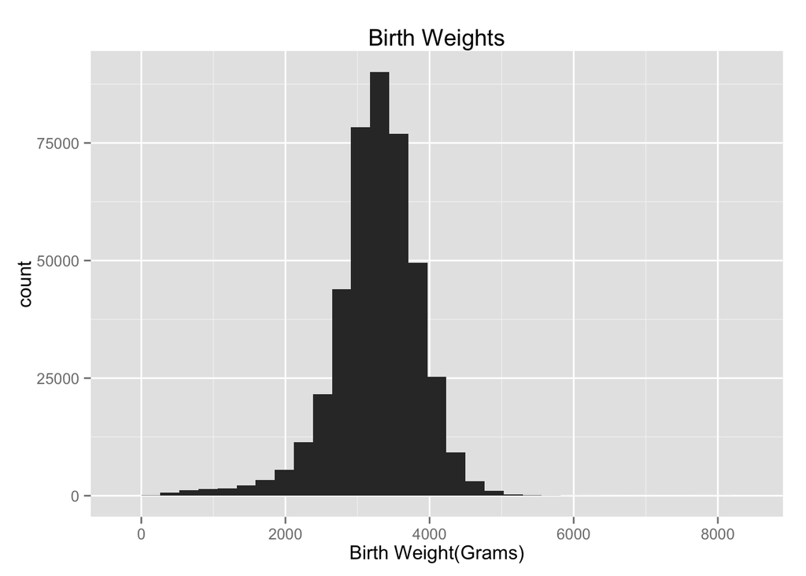

```r
birthw= ggplot(births2006.smpl,aes(x=DBWT)) +geom_histogram() +xlab("Birth Weight(Grams)") +ggtitle("Birth Weights")
birthw
```

# 8 -

Create two additional variables in which you bin Weight gains of mother and birth weight of baby into 4 different categories (for each) with approximately equal numbers in each category. Give the 4 bins understandable labels. Plot bar graphs for both these new variables.

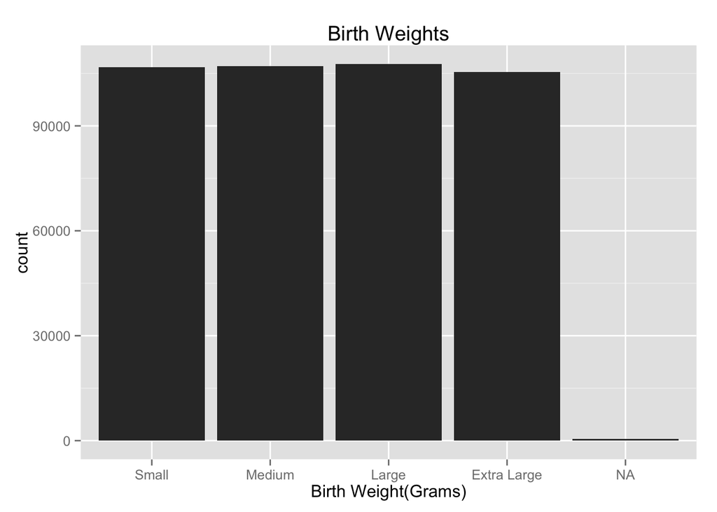

```r
births2006.smpl$DBWT.Cat <- with(births2006.smpl, bin.var(DBWT, bins=4, method='proportions',
   labels=c('Small','Medium','Large','Extra Large')))

birthwbin= ggplot(births2006.smpl,aes(x=DBWT.Cat)) +geom_bar() +xlab("Birth Weight(Grams)") +ggtitle("Birth Weights")
birthwbin
```

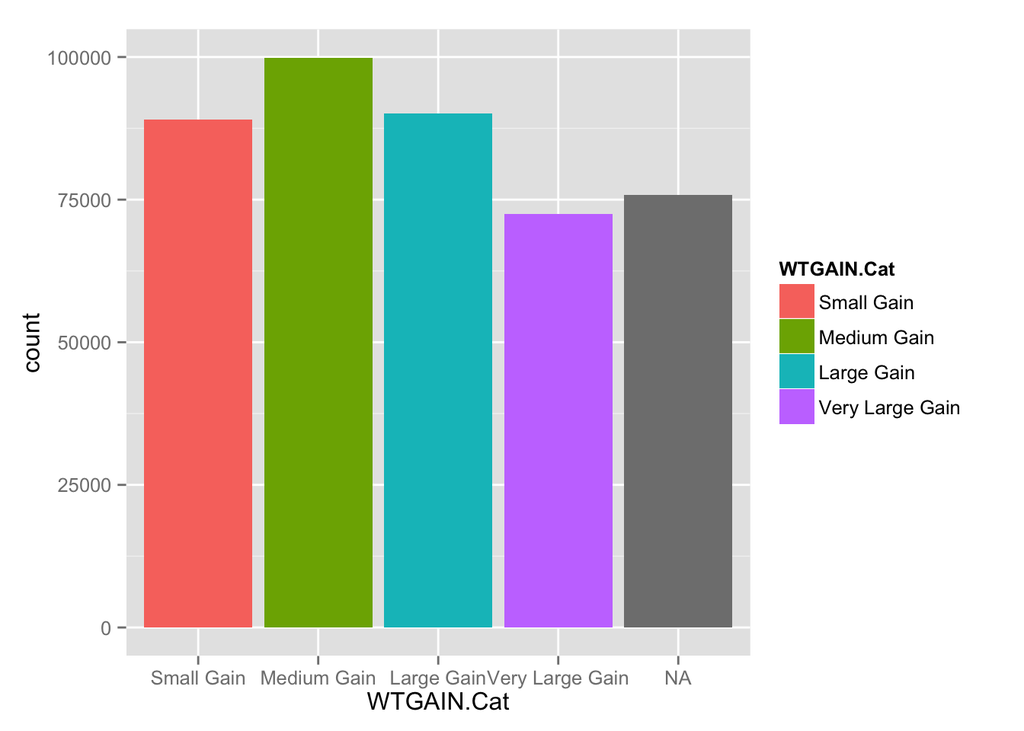

```r
births2006.smpl$WTGAIN.Cat <- with(births2006.smpl, bin.var(WTGAIN, bins=4, method='proportions',
   labels=c('Small Gain','Medium Gain','Large Gain','Very Large Gain')))

WTGAIN.Cat_bar= ggplot(births2006.smpl, aes(x=WTGAIN.Cat, fill=WTGAIN.Cat)) + geom_bar()
WTGAIN.Cat_bar
```

# 9 -

Is there a relationship between Weight gains of mother (4 bins) and birth weight of baby (4 bins)?

```r
births2006sub= births2006.smpl %>%
filter(WTGAIN!="NA" & DBWT.Cat!="NA")


cont=table(births2006sub$WTGAIN.Cat, births2006sub$DBWT.Cat)
cont
```

```
##
##                   Small Medium Large Extra Large
##   Small Gain      29511  23426 19949       16025
##   Medium Gain     25877  26638 25496       21798
##   Large Gain      19148  22700 24163       24040
##   Very Large Gain 13824  15402 19021       24177
```

```r
chisq.test(cont)
```

```
##
##  Pearson's Chi-squared test
##
## data:  cont
## X-squared = 9208.849, df = 9, p-value < 2.2e-16
```

```r
#ggplot(births2006sub, aes(x=WTGAIN, y=DBWT, color=DBWT.Cat)) +geom_point()+ geom_smooth(method=lm, color="black")
```

Judging from this p-value, there seems to be a significant relationship between these two factors. #- Is there a relationship between birth weight of baby (4 bins) and gender of baby?

```r
cont1=table(births2006sub$DBWT.Cat, births2006sub$SEX)

cont1
```

```
##
##                   F     M
##   Small       48463 39897
##   Medium      46192 41974
##   Large       42163 46466
##   Extra Large 34682 51358
```

```r
chisq.test(cont1)
```

```
##
##  Pearson's Chi-squared test
##
## data:  cont1
## X-squared = 4284.33, df = 3, p-value < 2.2e-16
```

Judging from this p-value, there seems to be a significant relationship between these two factors.

# 10 -

Plot a bar graph of delivery method (DMETH_REC)

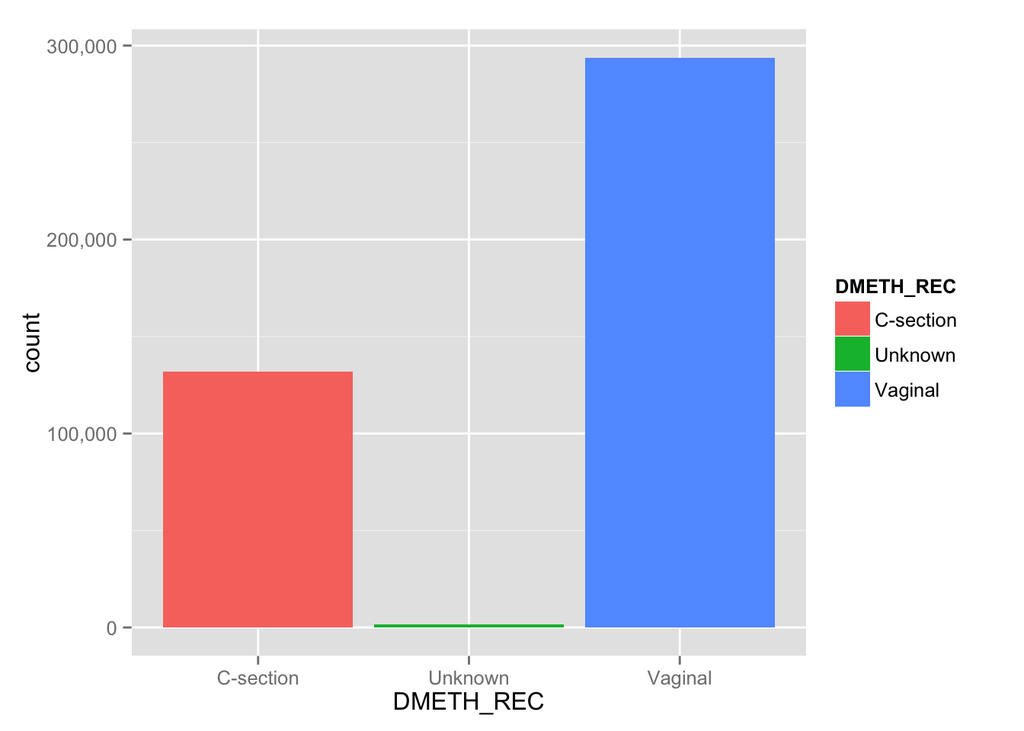

```r
ggplot(births2006.smpl, aes(x=DMETH_REC, fill=DMETH_REC)) + geom_bar() +scale_y_continuous(labels = comma)
```

# 11 -

Subset the dataset by removing the “Unknown” in Delivery method

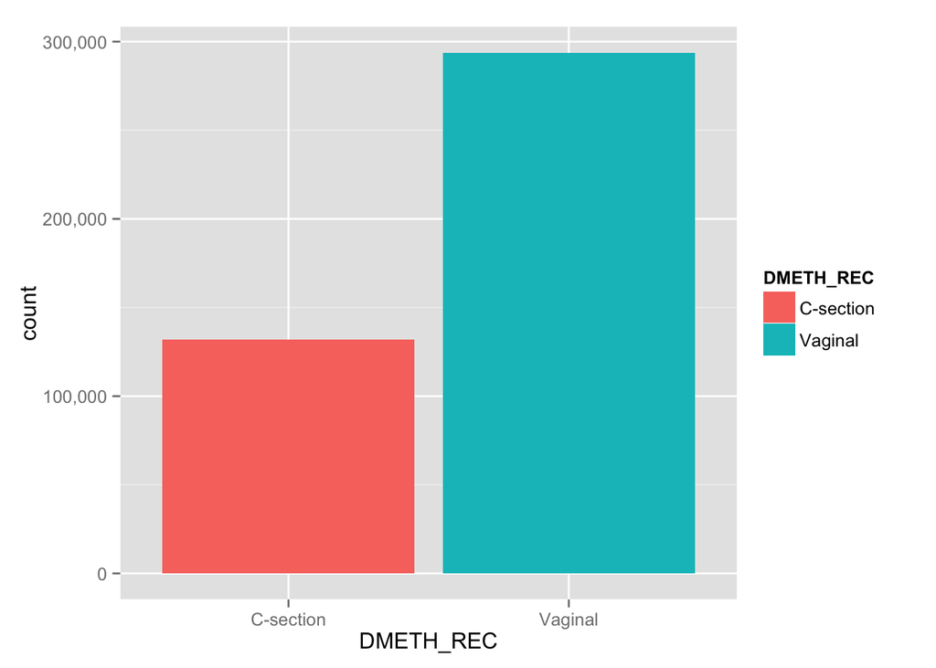

```r
births2006.smpl= births2006.smpl %>%
filter(DMETH_REC!="Unknown")

ggplot(births2006.smpl, aes(x=DMETH_REC, fill=DMETH_REC)) + geom_bar()+ scale_y_continuous(labels= comma)
```

1. Is there a relationship between delivery method (C-Section or Vaginal versus Day of the week)

```r
births2006sub= births2006.smpl %>%
filter(DMETH_REC!="Unknown")

births2006sub$DMETH_REC= factor(births2006sub$DMETH_REC)
cont2= table(births2006sub$DMETH_REC, births2006sub$DOB_WK)

cont2
```

```
##
##             Sunday Monday Tuesday Wednesday Thursday Friday Saturday
##   C-section   8836  20454   22921     23103    22825  23233    10696
##   Vaginal    31348  42031   46607     46935    47081  44858    34878
```

```r
chisq.test(cont2)
```

```
##
##  Pearson's Chi-squared test
##
## data:  cont2
## X-squared = 3474.49, df = 6, p-value < 2.2e-16
```

2. Plot bar graphs for number of deliveries on different days of week for both methods of deliveries.

```r
# subset1= births2006.smpl %>%
# select(DMETH_REC, DOB_WK) %>%
# filter(DMETH_REC!="Unknown")
#
# subset1$DMETH_REC= factor(subset1$DMETH_REC)
#
# birthsbardf2= table(subset1$DOB_WK,subset1$DMETH_REC)
# birthsbardf2=as.data.frame(birthsbardf2)
#
# birthsbardf2$Var1= factor(birthsbardf2$Var1,
# levels=c('1','2','3','4','5','6','7'),
# labels=c('Sunday','Monday', 'Tuesday', 'Wednesday', 'Thursday', 'Friday', 'Saturday'))
#
#
# birthsbarplot1 <- nPlot(Freq ~ Var1, group = 'Var2', data = birthsbardf2, type = 'multiBarChart')
#
# birthsbarplot1
```

[interactive chart not shown]

```r
cont3=table(births2006sub$DMETH_REC, births2006sub$SEX)

chisq.test(cont3)
```

```
##
##  Pearson's Chi-squared test with Yates' continuity correction
##
## data:  cont3
## X-squared = 207.5005, df = 1, p-value < 2.2e-16
```

4. Is there a relationship between delivery method and DPLURAL?

```r
cont4= table(births2006sub$DMETH_REC, births2006sub$DPLURAL)
cont4
```

```
##
##             1 Single 2 Twin 3 Triplet 4 Quadruplet 5 Quintuplet or higher
##   C-section   121431  10000       599           33                      5
##   Vaginal     290056   3634        42            6                      0
```

```r
chisq.test(cont4)
```

```
##
##  Pearson's Chi-squared test
##
## data:  cont4
## X-squared = 13085.12, df = 4, p-value < 2.2e-16
```